# UFPR PPGEcon 2024

Econometria (Prof. Adalto Acir Althaus Jr.): exercício 01

Alceu Nascimento, Thiago Soares e Aron Costa

2024-04-21

# Atividade A

**Dados**

A planilha “exemplo1.xls” contém informações referentes às seguintes variáveis:  
- NOTA: nota obtida na P1 por cada aluno da turma A de TPE no semestre passado;  
- ANTES: nota esperada por cada aluno antes de ver a prova;  
- APOS: nota esperada por cada aluno após a realização da prova;

```r
df1 <- read_csv2(here("econometria/data/exerc1.csv"))
```

```
## ℹ Using "','" as decimal and "'.'" as grouping mark. Use `read_delim()` for more control.
```

## Item 1: Mostre em um diagrama de dispersão a relação entre NOTA e ANTES.

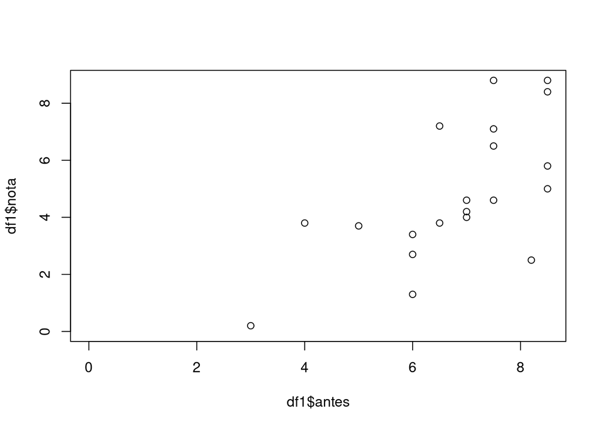

```r
plot(df1$nota ~ df1$antes, xlim = c(0, max(df1$antes)), ylim = c(0, max(df1$nota)))
```

**Ao rodar uma regressão de NOTA em ANTES, que valores você esperaria para $\beta_0$ $\beta_1$?**

Resposta:

> Para $\beta_0$ algo inferior a zero e para $\beta_1$ algo ligeiramente maior do que um.

## Item 2: Realize a regressão citada no item anterior de 2 formas distintas:

### 2(i) “manualmente”

**Isto é, calculando explicitamente os termos presentes na fórmula do estimador de MQO;**

Implementação computacional:

```r
# criando um dataframe para este exercicio
df_manual <- df1 |>
  select(nota, antes) |>
  rename(X = antes, Y = nota)
n <- nrow(df_manual)

# obter a média de X
mediaX <- mean(df_manual$X)
# obter a média de Y
mediaY <- mean(df_manual$Y)
# obter X centrado na média (x)
df_manual$x <- df_manual$X - mediaX
# obter Y centrado na média (y)
df_manual$y <- df_manual$Y - mediaY

# obter X^2
df_manual$x2 <- (df_manual$x)^2
# obter Y^2
df_manual$y2 <- (df_manual$y)^2
# obter produto xY
df_manual$xy <- df_manual$x*df_manual$y

# obter a soma de xY e de x^2
soma_x2 <- sum(df_manual$x2)
soma_xy <- sum(df_manual$xy)
soma_y2 <- sum(df_manual$y2)

# obter Beta
beta_estimado <- soma_xy/soma_x2
# obter Alpha
alpha_estimado <- mediaY - (beta_estimado*mediaX)

# Obter o y estimado
df_manual$Y_estimado <- alpha_estimado + beta_estimado * df_manual$X

# Obter os erros (resíduos)
df_manual$residuos <- df_manual$Y - df_manual$Y_estimado
df_manual$residuos2 <- df_manual$residuos^2

# Soma dos Quadrados
# SQE
sqe <- beta_estimado^2 * soma_x2
# SQT
sqt <- sum(df_manual$y2)
# SQR
sqr <- sum(df_manual$residuos2)
# R2
r2 <- sqe / sqt

# produzir tabela final com as variaveis incluidas e os valores de Alpha e Beta
df_manual
```

| Y | X | x | y | x2 | y2 | xy | Y_estimado | residuos | residuos2 |
| --- | --- | --- | --- | --- | --- | --- | --- | --- | --- |
| 2.7 | 6.0 | -0.81 | -2.12 | 0.6561 | 4.4944 | 1.7172 | 3.9894210746 | -1.2894210746 | 1.6626067075 |
| 5.8 | 8.5 | 1.69 | 0.98 | 2.8561 | 0.9604 | 1.6562 | 6.5529362766 | -0.7529362766 | 0.5669130365 |
| 7.2 | 6.5 | -0.31 | 2.38 | 0.0961 | 5.6644 | -0.7378 | 4.5021241150 | 2.6978758850 | 7.2785342911 |
| 3.4 | 6.0 | -0.81 | -1.42 | 0.6561 | 2.0164 | 1.1502 | 3.9894210746 | -0.5894210746 | 0.3474172031 |
| 8.8 | 7.5 | 0.69 | 3.98 | 0.4761 | 15.8404 | 2.7462 | 5.5275301958 | 3.2724698042 | 10.7090586197 |
| 4.6 | 7.0 | 0.19 | -0.22 | 0.0361 | 0.0484 | -0.0418 | 5.0148271554 | -0.4148271554 | 0.1720815688 |
| 5.0 | 8.5 | 1.69 | 0.18 | 2.8561 | 0.0324 | 0.3042 | 6.5529362766 | -1.5529362766 | 2.4116110790 |
| 2.5 | 8.2 | 1.39 | -2.32 | 1.9321 | 5.3824 | -3.2248 | 6.2453144523 | -3.7453144523 | 14.0273803467 |
| 8.4 | 8.5 | 1.69 | 3.58 | 2.8561 | 12.8164 | 6.0502 | 6.5529362766 | 1.8470637234 | 3.4116443985 |
| 8.8 | 8.5 | 1.69 | 3.98 | 2.8561 | 15.8404 | 6.7262 | 6.5529362766 | 2.2470637234 | 5.0492953772 |

[output cut: 10 more lines]

```r
# Criar um dataframe com os resultados
resultados <- data.frame(
  Objeto = c("beta_estimado", "alpha_estimado", "SQE", "SQR", "SQT", "R2"),
  Valor = c(beta_estimado, alpha_estimado, sqe, sqr, sqt, r2)
)
# Exibir a tabela formatada usando kable
xtable(resultados, col.names = c("Objeto", "Valor"), caption = "Tabela de Resultados da Regressão Linear")
```

| Objeto | Valor |
| --- | --- |
| beta_estimado | 1.0254060808 |
| alpha_estimado | -2.1630154102 |
| SQE | 45.4418958767 |
| SQR | 63.8501041233 |
| SQT | 109.2920000000 |
| R2 | 0.4157842832 |

### 2(ii) usando o comando interceptação e inclinação em fórmulas estatísticas.

Os valores estimados dos coeficientes deveriam, evidentemente, ser iguais para ambos os métodos.

**Tais coeficientes estão de acordo com o esperado no item 1?**

## Item 3: Calcule os resíduos da regressão e verifique que sua média é zero

(a menos de erros de arredondamento).

Obtenha uma estimativa da variância (e, portanto, do desvio padrão) do erro aleatório U do modelo.

```r
soma_residuos <- sum(df_manual$residuos)
media_residuos <- mean(df_manual$residuos)
variancia_residuos <- var(df_manual$residuos)
desviopadrao_residuos <- sd(df_manual$residuos)

# Criar um dataframe com os resultados
resultados_residuos <- data.frame(
  Objeto = c("Soma", "Média", "Variância", "Desvio Padrão"),
  Valor = c(soma_residuos, media_residuos, variancia_residuos, desviopadrao_residuos)
)
# Exibir a tabela formatada usando xtable
xtable(resultados_residuos, col.names = c("Objeto", "Valor"), caption = "Tabela de Resultados dos Resíduos da Regressão Linear")
```

| Objeto | Valor |
| --- | --- |
| Soma | -1.576516695e-14 |
| Média | -7.882881630e-16 |
| Variância | 3.360531796e+00 |
| Desvio Padrão | 1.833175331e+00 |

### Item 3a: Refaça os itens 2 e 3 utilizando a função do excel:

Dados > Análise de dados > Regressão

Implementação computacional:

```r
# NOTA : em substituição ao Excel foi usado o R, na funçaõ lm()
modelo1 <- lm(nota ~ antes, data = df1)
```

```r
stargazer(modelo1, type = "html", report = "vcstp*")
```

|  | *Dependent variable:* |
| --- | --- |
|  | nota |
| antes | 1.025 |
|  | (0.286) |
|  | t = 3.579 |
|  | p = 0.003*** |
| Constant | -2.163 |
|  | (1.996) |
|  | t = -1.084 |
|  | p = 0.293 |
| Observations | 20 |
| R<sup>2</sup> | 0.416 |
| Adjusted R<sup>2</sup> | 0.383 |
| Residual Std. Error | 1.883 (df = 18) |
| F Statistic | 12.811*** (df = 1; 18) |
| *Note:* | p<0.1; p<0.05; p<0.01 |

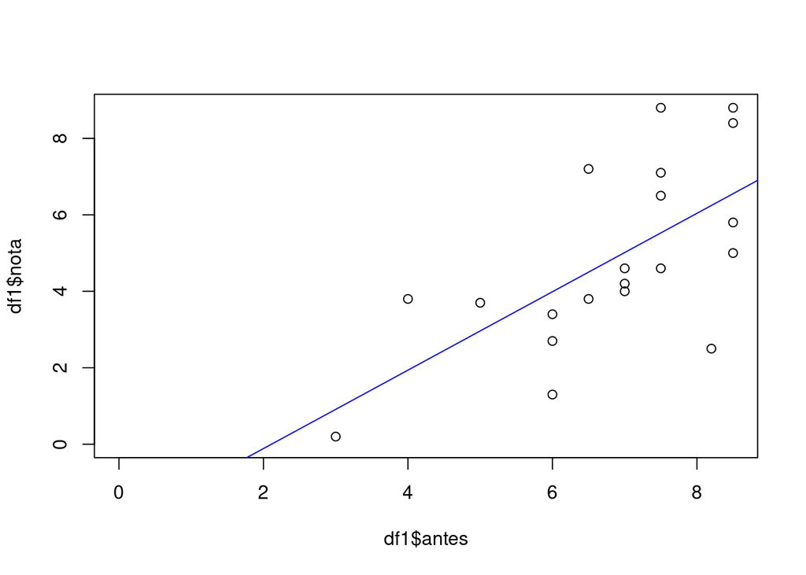

```r
plot(df1$nota ~ df1$antes, xlim = c(0, max(df1$antes)), ylim = c(0, max(df1$nota)))
abline(modelo1, col = "blue")
```

```r
soma_residuos_m1 <- sum(modelo1$residuals)
media_residuos_m1 <- mean(modelo1$residuals)
variancia_residuos_m1 <- var(modelo1$residuals)
desviopadrao_residuos_m1 <- sd(modelo1$residuals)

# Criar um dataframe com os resultados
resultados_residuos <- data.frame(
  Objeto = c("Soma", "Média", "Variância", "Desvio Padrão"),
  Valor = c(soma_residuos_m1, media_residuos_m1, variancia_residuos_m1, desviopadrao_residuos_m1)
)
# Exibir a tabela formatada usando xtable
xtable(resultados_residuos, col.names = c("Objeto", "Valor"), caption = "Tabela de Resultados dos Resíduos da Regressão Linear")
```

| Objeto | Valor |
| --- | --- |
| Soma | 1.221245327e-15 |
| Média | 6.104600332e-17 |
| Variância | 3.360531796e+00 |
| Desvio Padrão | 1.833175331e+00 |

## 4 Calcule o coeficiente de correlação amostral entre NOTA e ANTES de 2 formas distintas:

### 4.(i) “manualmente”

Isto é, aplicando explicitamente a fórmula adequada (note que a maior parte dos cálculos já foi feita no item 2.i acima);

A fórmula do coeficiente de correlação de Pearson é dada por:

$$r = \frac{\sum{(x_i - \bar{x})(y_i - \bar{y})}}{\sqrt{\sum{(x_i -
\bar{x})^2} \sum{(y_i - \bar{y})^2}}}$$

Onde:  
- $r$ é o coeficiente de correlação.  
- $x_i$ e $y_i$ são os valores das observações de $x$ e $y$.  
- $\bar{x}$ e $\bar{y}$ são as médias de $x$ e $y$, respectivamente.  
- $\sum{(x_i - \bar{x})(y_i - \bar{y})}$ é a soma dos produtos das variáveis centralizadas.  
- $\sum{(x_i - \bar{x})^2}$ é a soma dos quadrados das variáveis $x$ centralizadas.  
- $\sum{(y_i - \bar{y})^2}$ é a soma dos quadrados das variáveis $y$ centralizadas.

```r
# Calcular o coeficiente de correlação
soma_xy / sqrt(soma_x2 * soma_y2)
```

```
## [1] 0.6448133708
```

### 4.(ii) usando a função estatística CORREL.

Verifique que o R2 da regressão do item anterior corresponde ao quadrado desse coeficiente de correlação.

```r
correl <- correlation::correlation(df1)
correl
```

|  | Parameter1 | Parameter2 | r | CI | CI_low | CI_high | t | df_error | p | Method | n_Obs |
| --- | --- | --- | --- | --- | --- | --- | --- | --- | --- | --- | --- |
| 1 | antes | apos | 0.8039884002 | 0.95 | 0.5610948157 | 0.9194026565 | 5.736252744 | 18 | 0.00003885707674 | Pearson correlation | 20 |
| 2 | antes | nota | 0.6448133708 | 0.95 | 0.2830626139 | 0.8459484236 | 3.579181061 | 18 | 0.00214422158443 | Pearson correlation | 20 |
| 3 | apos | nota | 0.8402885639 | 0.95 | 0.6332320499 | 0.9350977723 | 6.575877804 | 18 | 0.00001062462769 | Pearson correlation | 20 |

```r
correl$r[2]^2
```

```
## [1] 0.4157842832
```

```r
r2
```

```
## [1] 0.4157842832
```

## 5 Realize a regressão de NOTA (variável dependente) em ANTES (variável independente)

Suponha que o intercepto seja zero (ou seja, excluindo o termo constante do modelo).

Implementação computacional:

```r
# Ajustar o modelo de regressão sem intercepto (-1)
modelo2 <- lm(nota ~ antes - 1, data = df1)
```

```r
stargazer(modelo2, type = "html", report = "vcstp*")
```

|  | *Dependent variable:* |
| --- | --- |
|  | nota |
| antes | 0.722 |
|  | (0.061) |
|  | t = 11.888 |
|  | p = 0.000*** |
| Observations | 20 |
| R<sup>2</sup> | 0.881 |
| Adjusted R<sup>2</sup> | 0.875 |
| Residual Std. Error | 1.892 (df = 19) |
| F Statistic | 141.328*** (df = 1; 19) |
| *Note:* | p<0.1; p<0.05; p<0.01 |

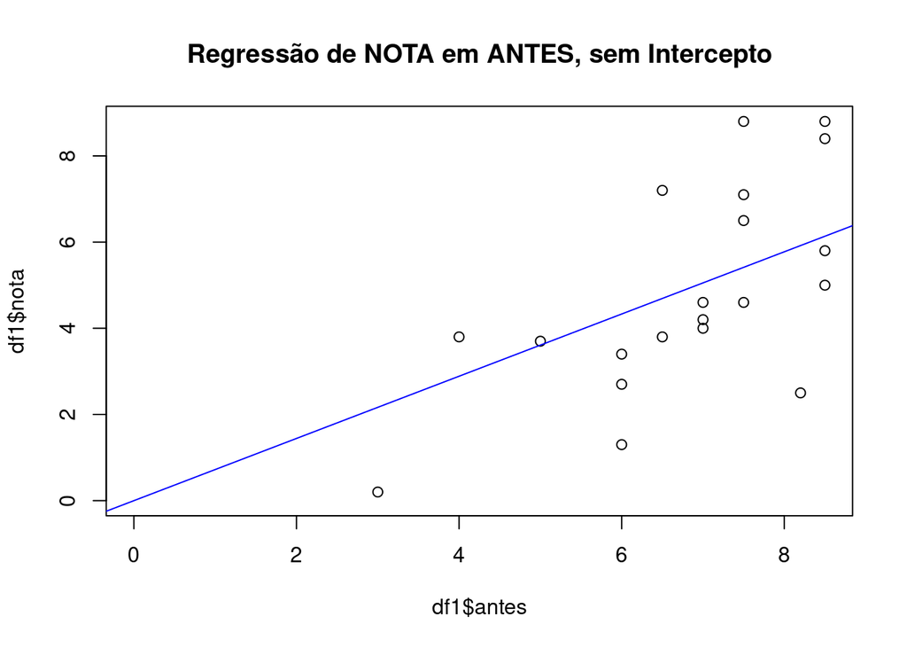

```r
# Plotar os dados e a linha de regressão ajustada
plot(df1$nota ~ df1$antes,
     xlim = c(0, max(df1$antes)),
     ylim = c(0, max(df1$nota)),
     main = "Regressão de NOTA em ANTES, sem Intercepto")
abline(modelo2, col = "blue")
```

**Calcule a soma dos resíduos da regressão e compare com o resultado obtido no item 3.**

```r
soma_residuos_modelo2 <- sum(modelo2$residuals)
print(paste("Soma dos Resíduos do Modelo 2 (sem intercepto):", soma_residuos_modelo2))
```

```
## [1] "Soma dos Resíduos do Modelo 2 (sem intercepto): -1.92597811978491"
```

```r
print(paste("Soma dos Resíduos do Modelo 1 (com intercepto):", soma_residuos))
```

```
## [1] "Soma dos Resíduos do Modelo 1 (com intercepto): -0.0000000000000157651669496772"
```

## 6 Teste de Hipóteses

Um teste da hipótese de racionalidade das expectativas se basearia na hipótese nula
$$H_0 : \beta_0 = 0 \; \text{e} \; \beta 1=1$$

Com base nos valores estimados, gostaríamos de testar tal hipótese.  
Veremos formalmente no curso como testar hipóteses conjuntas como essa.  
Informalmente, porém, já podemos dizer alguma coisa a respeito dessa hipótese?  
Ela parece razoável dados os betas e seus respectivos desvios padrões estimados nos modelos com e sem intercepto acima?

Resposta:

Para realizar o teste de hipóteses mencionado e avaliar a racionalidade das expectativas, onde a hipótese nula é $H_0: \beta_0 = 0$ e $\beta_1 = 1$, podemos usar os coeficientes estimados e seus desvios padrão obtidos nos modelos de regressão com e sem intercepto.

### Teste Informal de Hipóteses

A ideia aqui é verificar se os coeficientes estimados são significativamente diferentes dos valores postulados pela hipótese nula.

#### Modelo com Intercepto

- $\beta_0$ estimado: -2.163 (desvio padrão: 1.996)
- $\beta_1$ estimado: 1.025 (desvio padrão: 0.286)

#### Modelo sem Intercepto

- $\beta_1$ estimado: 0.722 (desvio padrão: 0.061)

Vamos calcular os valores $t$ para cada coeficiente e comparar com o valor crítico da distribuição $t$ de Student para um nível de significância típico (por exemplo, 0.05).

### Modelo com Intercepto

#### Teste para $\beta_0 = 0$

$$t_{\beta_0} = \frac{\beta_0 -
0}{\text{desvio padrão de } \beta_0} = \frac{-2.163}{1.996} = -1.084$$

#### Teste para $\beta_1 = 1$

$$t_{\beta_1} = \frac{\beta_1 -
1}{\text{desvio padrão de } \beta_1} = \frac{1.025 - 1}{0.286} = 0.087$$

### Modelo sem Intercepto

#### Teste para $\beta_1 = 1$

$$t_{\beta_1} = \frac{\beta_1 -
1}{\text{desvio padrão de } \beta_1} = \frac{0.722 - 1}{0.061} = -4.557$$

### Avaliação dos Resultados

Para avaliar esses valores $t$, podemos compará-los com o valor crítico da distribuição $t$ de Student com o nível de significância escolhido. Para $\alpha = 0.05$ e 18 graus de liberdade (considerando 20 observações e 2 parâmetros no modelo), o valor crítico é aproximadamente 2.101.

- **Para $\beta_0 = 0$**:
  - $t_{\beta_0} = -1.084$, que é menor em valor absoluto do que o valor crítico de 2.101. Portanto, não rejeitamos $H_0$ ao nível de significância de 0.05.
- **Para $\beta_1 = 1$ no modelo com intercepto**:
  - $t_{\beta_1} = 0.087$, que é muito menor do que o valor crítico de 2.101. Portanto, não rejeitamos $H_0$ ao nível de significância de 0.05.
- **Para $\beta_1 = 1$ no modelo sem intercepto**:
  - $t_{\beta_1} = -4.557$, que é maior em valor absoluto do que o valor crítico de 2.101. Portanto, rejeitamos $H_0$ ao nível de significância de 0.05.

### Conclusão Informal

A hipótese de que $\beta_0 = 0$ e $\beta_1 = 1$ é razoável para o modelo com intercepto, pois não rejeitamos as hipóteses nulas associadas a esses coeficientes ao nível de significância de 0.05. No entanto, para o modelo sem intercepto, rejeitamos a hipótese de que $\beta_1 = 1$.

Portanto, baseado nos testes informais: - **Com intercepto**: A hipótese parece razoável. - **Sem intercepto**: A hipótese não parece razoável, pois $\beta_1$ é significativamente diferente de 1.

Implementação computacional:

```r
# Ajustar os modelos
modelo_com_intercepto <- lm(nota ~ antes, data = df1)
modelo_sem_intercepto <- lm(nota ~ antes - 1, data = df1)

# Coeficientes e desvios padrões
coef_com_intercepto <- coef(summary(modelo_com_intercepto))
coef_sem_intercepto <- coef(summary(modelo_sem_intercepto))

# Valores t para o modelo com intercepto
t_beta0 <- coef_com_intercepto[1, "Estimate"] / coef_com_intercepto[1, "Std. Error"]
t_beta1_com_intercepto <- (coef_com_intercepto[2, "Estimate"] - 1) / coef_com_intercepto[2, "Std. Error"]

# Valores t para o modelo sem intercepto
t_beta1_sem_intercepto <- (coef_sem_intercepto[1, "Estimate"] - 1) / coef_sem_intercepto[1, "Std. Error"]

# Resultados
resultados_hipotese <- data.frame(
  Modelo = c("Com Intercepto", "Com Intercepto", "Sem Intercepto"),
  Coeficiente = c("beta0", "beta1", "beta1"),
  t_value = c(t_beta0, t_beta1_com_intercepto, t_beta1_sem_intercepto)
)

# Exibir os resultados
print(kable(resultados_hipotese,
             col.names = c("Modelo", "Coeficiente", "Valor t"),
             caption = "Teste de Hipóteses para os Coeficientes da Regressão Linear"),
      type = "html")
```

```
##
##
## Table: Teste de Hipóteses para os Coeficientes da Regressão Linear
##
## |Modelo         |Coeficiente |       Valor t|
## |:--------------|:-----------|-------------:|
## |Com Intercepto |beta0       | -1.0837046302|
## |Com Intercepto |beta1       |  0.0886799532|
## |Sem Intercepto |beta1       | -4.5791720300|
```

## 7 Realize essa regressão com o regressor adicional a variável (APOS – ANTES) (usando Análise de Dados) e compare com os resultados acima.

A nota esperada por cada aluno reflete diversos fatores, em particular: (i) grau de dificuldade esperado da prova; (ii) nível esperado de exigência na correção; (iii) nível de conhecimento da matéria percebido pelo aluno.

Os desvios da nota efetiva em relação à esperada refletem, assim, erros referentes a cada uma dessas expectativas.

**Qual seria, então, a diferença entre o modelo estimado acima e um segundo modelo, no qual incluíssemos como regressor adicional a variável (APOS – ANTES)?**  
**Realize essa regressão (usando Análise de Dados) e compare com os resultados acima.**

```r
df7 <- df1
df7$apos_antes  <-  df7$apos - df7$antes
modelo7 <- lm(nota ~ antes + apos_antes, data = df7)
```

```r
stargazer(modelo7, type = "html", report = "vcstp*")
```

|  | *Dependent variable:* |
| --- | --- |
|  | nota |
| antes | 1.302 |
|  | (0.219) |
|  | t = 5.956 |
|  | p = 0.00002*** |
| apos_antes | 1.441 |
|  | (0.348) |
|  | t = 4.135 |
|  | p = 0.001*** |
| Constant | -2.413 |
|  | (1.451) |
|  | t = -1.662 |
|  | p = 0.115 |
| Observations | 20 |
| R<sup>2</sup> | 0.709 |
| Adjusted R<sup>2</sup> | 0.674 |
| Residual Std. Error | 1.368 (df = 17) |
| F Statistic | 20.686*** (df = 2; 17) |
| *Note:* | p<0.1; p<0.05; p<0.01 |

## 8 Realize agora a regressão de NOTA contra ANTES e APOS e compare com os resultados do item 7.

```r
modelo8 <- lm(nota ~ antes + apos, data = df1)
```

```r
stargazer(modelo8, modelo7, type = "html", report = "vcstp*")
```

|  | *Dependent variable:* |  |
| --- | --- | --- |
|  | nota |  |
|  | (1) | (2) |
| antes | -0.138 | 1.302 |
|  | (0.350) | (0.219) |
|  | t = -0.395 | t = 5.956 |
|  | p = 0.698 | p = 0.00002*** |
| apos | 1.441 |  |
|  | (0.348) |  |
|  | t = 4.135 |  |
|  | p = 0.001*** |  |
| apos_antes |  | 1.441 |
|  |  | (0.348) |
|  |  | t = 4.135 |
|  |  | p = 0.001*** |
| Constant | -2.413 | -2.413 |
|  | (1.451) | (1.451) |
|  | t = -1.662 | t = -1.662 |
|  | p = 0.115 | p = 0.115 |
| Observations | 20 | 20 |
| R<sup>2</sup> | 0.709 | 0.709 |
| Adjusted R<sup>2</sup> | 0.674 | 0.674 |
| Residual Std. Error (df = 17) | 1.368 | 1.368 |
| F Statistic (df = 2; 17) | 20.686*** | 20.686*** |
| *Note:* | p<0.1; p<0.05; p<0.01 |  |

# Atividade B

A planilha exemplo2.xls contém informações referentes às seguintes variáveis:  
- PIBPC – PIB per capita dos estados brasileiros, em R$ mil referente ao ano 20xx;  
- ETOT – número médio de anos de estudo da população total de cada estado.  
A planilha já inclui diversas transformações dessas variáveis (mudanças de unidades de medida, logaritmos etc.).

```r
dfb <- read_csv2(here("econometria/data/exerc2.csv"))
```

```
## ℹ Using "','" as decimal and "'.'" as grouping mark. Use `read_delim()` for more control.
```

```r
head(dfb)
```

| estado | pibpc | pibpc1000 | ln_pibpc | ln_pibpc1000 | etot | etot12 | ln_etot | ln_etot12 |
| --- | --- | --- | --- | --- | --- | --- | --- | --- |
| AC | 3.09 | 3090 | 1.13 | 8.04 | 6.27 | 75.24 | 1.84 | 4.32 |
| AL | 2.49 | 2490 | 0.91 | 7.82 | 4.15 | 49.80 | 1.42 | 3.91 |
| AM | 6.11 | 6110 | 1.81 | 8.72 | 6.20 | 74.40 | 1.82 | 4.31 |
| AP | 3.71 | 3710 | 1.31 | 8.22 | 6.28 | 75.36 | 1.84 | 4.32 |
| BA | 3.51 | 3510 | 1.26 | 8.16 | 3.97 | 47.64 | 1.38 | 3.86 |
| CE | 2.88 | 2880 | 1.06 | 7.97 | 4.03 | 48.36 | 1.39 | 3.88 |

## 1 Realize a regressão de PIBPC em ETOT.

```r
modelo.b1.a <- lm(pibpc ~ etot, data = dfb)
```

```r
stargazer(modelo.b1.a, type = "html", report = "vcstp*", digits = 5)
```

|  | *Dependent variable:* |
| --- | --- |
|  | pibpc |
| etot | 1.55969 |
|  | (0.33314) |
|  | t = 4.68182 |
|  | p = 0.00009*** |
| Constant | -3.76515 |
|  | (1.87117) |
|  | t = -2.01219 |
|  | p = 0.05510* |
| Observations | 27 |
| R<sup>2</sup> | 0.46717 |
| Adjusted R<sup>2</sup> | 0.44586 |
| Residual Std. Error | 1.99721 (df = 25) |
| F Statistic | 21.91942*** (df = 1; 25) |
| *Note:* | p<0.1; p<0.05; p<0.01 |

```r
check_autocorrelation(modelo1)
```

```
## OK: Residuals appear to be independent and not autocorrelated (p = 0.758).
```

```r
check_normality(modelo1)
```

```
## OK: residuals appear as normally distributed (p = 0.376).
```

```r
check_heteroscedasticity(modelo1)
```

```
## OK: Error variance appears to be homoscedastic (p = 0.363).
```

**Com base no que você estudou no curso, como você esperaria que mudassem os coeficientes estimados ao mudar a unidade de medida da variável dependente,passando a medi-la em R$ em vez de R$ mil?**

> Quando mudamos a unidade de medida da variável dependente de R$ mil para R$ (ou seja, multiplicamos PIBPC por 1000 para obter PIBPC1000), esperamos que o coeficiente associado a ETOT aumente em um fator de 1000.

**Verifique que sua expectativa está correta, estimando a regressão de (PIBPC*1000) em ETOT.**

```r
modelo.b1.b <- lm(pibpc1000 ~ etot, data = dfb)
```

```r
stargazer(modelo.b1.b, type = "html", report = "vcstp*", digits = 5)
```

|  | *Dependent variable:* |
| --- | --- |
|  | pibpc1000 |
| etot | 1,559.68892 |
|  | (333.13742) |
|  | t = 4.68182 |
|  | p = 0.00009*** |
| Constant | -3,765.14925 |
|  | (1,871.17092) |
|  | t = -2.01219 |
|  | p = 0.05510* |
| Observations | 27 |
| R<sup>2</sup> | 0.46717 |
| Adjusted R<sup>2</sup> | 0.44586 |
| Residual Std. Error | 1,997.21266 (df = 25) |
| F Statistic | 21.91942*** (df = 1; 25) |
| *Note:* | p<0.1; p<0.05; p<0.01 |

> Os resultados do segundo modelo confirmam a expectativa.

## 2 Realize a regressão de LN(PIBPC) em ETOT.

```r
modelo.b2.a <- lm(ln_pibpc ~ etot, data = dfb)
```

```r
stargazer(modelo.b2.a, type = "html", report = "vcstp*", digits = 5)
```

|  | *Dependent variable:* |
| --- | --- |
|  | ln_pibpc |
| etot | 0.31343 |
|  | (0.06668) |
|  | t = 4.70085 |
|  | p = 0.00009*** |
| Constant | -0.29295 |
|  | (0.37451) |
|  | t = -0.78224 |
|  | p = 0.44143 |
| Observations | 27 |
| R<sup>2</sup> | 0.46919 |
| Adjusted R<sup>2</sup> | 0.44796 |
| Residual Std. Error | 0.39973 (df = 25) |
| F Statistic | 22.09798*** (df = 1; 25) |
| *Note:* | p<0.1; p<0.05; p<0.01 |

**Como muda a interpretação dos coeficientes estimados em relação ao item anterior?**

> Quando transformamos PIBPC para seu logaritmo natural (ln_pibpc) e regredimos sobre ETOT, o coeficiente passa a ser interpretado como a variação percentual no PIB per capita associada a um ano adicional de estudo. Isso significa que cada ano adicional de estudo está associado a um aumento de aproximadamente 31.3% no PIB per capita.

**Com base no que você estudou no curso, como você esperaria que mudassem os coeficientes estimados ao mudar a unidade de medida da variável dependente, passando a medi-la em R$ em vez de R$ mil?**

**E ao mudar a unidade de medida da variável explicativa, passando a medi-la em meses em vez de anos?**

**Verifique que suas expectativas estão corretas, estimando as regressões de LN(PIBPC*1000) em ETOT e de LN(PIBPC) em (ETOT*12).**

```r
modelo.b2b.1 <- lm(ln_pibpc1000 ~ etot, data = dfb)
modelo.b2b.2 <- lm(ln_pibpc1000 ~ etot12, data = dfb)
```

```r
stargazer(modelo.b2b.1,modelo.b2b.2, type = "html", report = "vcstp*", digits = 5)
```

|  | *Dependent variable:* |  |
| --- | --- | --- |
|  | ln_pibpc1000 |  |
|  | (1) | (2) |
| etot | 0.31443 |  |
|  | (0.06677) |  |
|  | t = 4.70914 |  |
|  | p = 0.00008*** |  |
| etot12 |  | 0.02620 |
|  |  | (0.00556) |
|  |  | t = 4.70914 |
|  |  | p = 0.00008*** |
| Constant | 6.60936 | 6.60936 |
|  | (0.37503) | (0.37503) |
|  | t = 17.62345 | t = 17.62345 |
|  | p = 0.00000*** | p = 0.00000*** |
| Observations | 27 | 27 |
| R<sup>2</sup> | 0.47007 | 0.47007 |
| Adjusted R<sup>2</sup> | 0.44887 | 0.44887 |
| Residual Std. Error (df = 25) | 0.40029 | 0.40029 |
| F Statistic (df = 1; 25) | 22.17596*** | 22.17596*** |
| *Note:* | p<0.1; p<0.05; p<0.01 |  |

## 3 Realize a regressão de LN(PIBPC) em ETOT e (ETOT*12).

```r
modelob.3b.1 <- lm(ln_pibpc ~ etot, data = dfb)
modelob.3b.2 <- lm(ln_pibpc ~ etot12, data = dfb)
```

```r
stargazer(modelob.3b.1,modelob.3b.2, type = "html", report = "vcstp*", digits = 5)
```

|  | *Dependent variable:* |  |
| --- | --- | --- |
|  | ln_pibpc |  |
|  | (1) | (2) |
| etot | 0.31343 |  |
|  | (0.06668) |  |
|  | t = 4.70085 |  |
|  | p = 0.00009*** |  |
| etot12 |  | 0.02612 |
|  |  | (0.00556) |
|  |  | t = 4.70085 |
|  |  | p = 0.00009*** |
| Constant | -0.29295 | -0.29295 |
|  | (0.37451) | (0.37451) |
|  | t = -0.78224 | t = -0.78224 |
|  | p = 0.44143 | p = 0.44143 |
| Observations | 27 | 27 |
| R<sup>2</sup> | 0.46919 | 0.46919 |
| Adjusted R<sup>2</sup> | 0.44796 | 0.44796 |
| Residual Std. Error (df = 25) | 0.39973 | 0.39973 |
| F Statistic (df = 1; 25) | 22.09798*** | 22.09798*** |
| *Note:* | p<0.1; p<0.05; p<0.01 |  |

**O que acontece com os coeficientes estimados e seus desvios padrões?**

> No modelo PIBPC em ETOT, o coeficiente de 1,560 indica que cada ano adicional de estudo está associado a um aumento de 1,560 no PIB per capita em mil reais. Com a mudança na unidade da variável dependente, no modelo PIBPC1000 em ETOT, o coeficiente de 1.560,00 confirma a expectativa de multiplicação por 1000 ao mudar a unidade de medida do PIB per capita de mil reais para reais. Já no modelo de ln(PIBPC) em ETOT, o coeficiente de 0.313 significa que cada ano adicional de estudo está associado a um aumento de aproximadamente 31.3% no PIB per capita. Com a mudança na unidade da variável explicativa, no modelo ln(PIBPC) em ETOT12, o coeficiente de 0.026 confirma a expectativa de divisão por 12 ao mudar a unidade de medida dos anos de estudo para meses.

**Compare com os resultados do item anterior.**

> Os coeficientes mantêm a relação esperada conforme mudamos a unidade das variáveis dependentes e explicativas. A transformação logarítmica muda a interpretação dos coeficientes de um efeito absoluto para um efeito percentual. Os desvios-padrão dos coeficientes também se ajustam conforme esperado, mantendo a significância estatística dos coeficientes.